# Pig PA ultrasound data

## Read in Data

```r
readxl::read_excel(here("PIG PAUS data_yc.xlsx")) %>%
  janitor::clean_names() |>
  janitor::remove_empty() |>
  mutate(measurement_value = as.numeric(measurement_value)) ->
df
```

```
value for "which" not specified, defaulting to c("rows", "cols")
```

## Analysis

```r
df |>
  group_by(pig, treated, wavelength) |>
  summarise(mean = mean(measurement_value, na.rm=TRUE),
            sd = sd(measurement_value, na.rm=TRUE)) |>
  gt() |>
  tab_header(
    title = md("Data Grouped by Pig, Treatment, and Wavelength")
  )
```

```
can override using the `.groups` argument.
```

Data Grouped by Pig, Treatment, and Wavelength

| wavelength | mean | sd |
| --- | --- | --- |
| PAPC-1 - 0 |  |  |
| 800 | 4283.677 | 423.8885 |
| 1200 | 3634.495 | 301.0695 |
| PAPC-1 - 1 |  |  |
| 800 | 6255.793 | 203.0605 |
| 1200 | 5340.887 | 573.8289 |
| PAPC-3 - 0 |  |  |
| 750 | 4633.550 | 143.4739 |
| 800 | 4625.280 | 309.0905 |
| 1200 | 3810.645 | 528.7532 |
| 1310 | 3709.348 | 535.2551 |
| PAPC-3 - 1 |  |  |
| 800 | 6751.210 | 450.3719 |
| 1200 | 6448.237 | 622.0233 |
| 1310 | 5500.300 | 121.5375 |

```r
df |>
  group_by(treated, wavelength) |>
  summarise(mean = mean(measurement_value, na.rm=TRUE),
            sd = sd(measurement_value, na.rm=TRUE)) |>
  gt() |>
  tab_header(
    title = md("Data Grouped by Treatment (0/1) and Wavelength")
  )
```

Data Grouped by Treatment (0/1) and Wavelength

| wavelength | mean | sd |
| --- | --- | --- |
| 0 |  |  |
| 750 | 4633.550 | 143.4739 |
| 800 | 4369.078 | 408.6534 |
| 1200 | 3678.533 | 333.6674 |
| 1310 | 3709.348 | 535.2551 |
| 1 |  |  |
| 800 | 6503.502 | 413.8341 |
| 1200 | 5894.562 | 808.9155 |
| 1310 | 5500.300 | 121.5375 |

We can perform unpaired t tests without regard to pig or esophageal location

```r
df |>
  filter(wavelength == 800) |>
  rstatix::t_test(measurement_value ~ treated, var.equal = TRUE)
```

```
# A tibble: 1 × 8
  .y.      group1 group2    n1    n2 statistic    df       p
* <chr>    <chr>  <chr>  <int> <int>     <dbl> <dbl>   <dbl>
1 measure… 0      1          8     6     -9.62    12 5.43e-7
```

```r
df |>
  filter(wavelength == 1200) |>
  rstatix::t_test(measurement_value ~ treated, var.equal = TRUE)
```

```
# A tibble: 1 × 8
  .y.      group1 group2    n1    n2 statistic    df       p
* <chr>    <chr>  <chr>  <int> <int>     <dbl> <dbl>   <dbl>
1 measure… 0      1          8     6     -7.06    12 1.32e-5
```

```r
df |>
  filter(wavelength ==1310) |>
  rstatix::t_test(measurement_value ~ treated, var.equal = TRUE)
```

```
# A tibble: 1 × 8
  .y.      group1 group2    n1    n2 statistic    df       p
* <chr>    <chr>  <chr>  <int> <int>     <dbl> <dbl>   <dbl>
1 measure… 0      1          5     2     -4.44     5 0.00675
```

There appear to be significant differences between treated and untreated pigs at all wavelengths. The differences are most pronounced at 800 nm.

# Modeling measurement values

```r
model <- lm(measurement_value ~ pig + treated + site_cm, data = df |> filter(wavelength == 800))

model |>
  broom::tidy()
```

```
# A tibble: 4 × 5
  term        estimate std.error statistic    p.value
  <chr>          <dbl>     <dbl>     <dbl>      <dbl>
1 (Intercept)  4047.       498.      8.12  0.0000103
2 pigPAPC-3     411.       222.      1.85  0.0939
3 treated      2020.       215.      9.38  0.00000284
4 site_cm         5.77      12.6     0.456 0.658
```

Even with this small N, there is some variance from pig to pig at 800 nm. There is a trend toward higher values for Pig 3. There is a significant difference between treated and untreated pigs. Treatment increases signal at 800 nm by ~ 2020 AU. There is minimal difference between the different esophageal sites (with this small N). We are not controlling for pig age, which might correlate with higher signals.

```r
model <- lm(measurement_value ~ pig + treated + site_cm, data = df |> filter(wavelength == 1200))

model |>
  broom::tidy()
```

```
# A tibble: 4 × 5
  term        estimate std.error statistic   p.value
  <chr>          <dbl>     <dbl>     <dbl>     <dbl>
1 (Intercept)   4014.      670.      5.99  0.000134
2 pigPAPC-3      659.      298.      2.21  0.0516
3 treated       2078.      289.      7.18  0.0000301
4 site_cm        -13.2      17.0    -0.775 0.457
```

Even with this small N, there is some variance from pig to pig at 1200 nm. There is a trend toward higher values for Pig 3. There is a significant difference between treated and untreated pigs. Treatment increases signal at 1200 nm by ~ 2078 AU. There is minimal difference between the different esophageal sites (with this small N). We are not controlling for pig age, which might correlate with higher signals.

```r
model <- lm(measurement_value ~ treated + site_cm,
            data = df |> filter(wavelength == 1310))

model |>
  broom::tidy()
```

```
# A tibble: 3 × 5
  term        estimate std.error statistic p.value
  <chr>          <dbl>     <dbl>     <dbl>   <dbl>
1 (Intercept)   3181.     1238.      2.57   0.0620
2 treated       1857.      466.      3.99   0.0163
3 site_cm         13.2      30.4     0.434  0.686
```

Only one pig was evaluated at 1310 nm. There is a significant difference between treated and untreated pigs.Treatment increases signal at 1310 nm by ~ 1857 AU. There is minimal difference between the different esophageal sites (with this small N). We are not controlling for pig age, which might correlate with higher signals.

## Let’s look at paired t-tests - in the same pig at the same site.

First, let’s look at the differencs at 800 nm

```r
df |>
  filter(wavelength == 800) |>
             arrange(pig, site_cm, treated) |>
  filter(lag(site_cm) == site_cm | lead(site_cm) == site_cm) |>
  mutate(diff = measurement_value - lag(measurement_value)) |>
  filter(treated ==1) |>
  gt()
```

| pig | date | site_cm | wavelength | treated | measurement_value | diff |
| --- | --- | --- | --- | --- | --- | --- |
| PAPC-1 | 2024-06-25 | 30 | 800 | 1 | 6162.62 | 1612.88 |
| PAPC-1 | 2024-06-25 | 40 | 800 | 1 | 6488.72 | 1703.53 |
| PAPC-1 | 2024-06-25 | 50 | 800 | 1 | 6116.04 | 1463.56 |

Now let’s perform the paired t-test at 800 nm - in two ways, first by looking at the differences in the same pig at the same site, then by using the official paired t test.

```r
df |>
  filter(wavelength == 800) |>
             arrange(pig, site_cm, treated) |>
  filter(lag(site_cm) == site_cm | lead(site_cm) == site_cm) |>
  mutate(diff = measurement_value - lag(measurement_value)) |>
  filter(treated ==1) |>
  rstatix::t_test(diff ~ 1, mu = 0)
```

```
# A tibble: 1 × 7
  .y.   group1 group2         n statistic    df       p
* <chr> <chr>  <chr>      <int>     <dbl> <dbl>   <dbl>
1 diff  1      null model     3      22.8     2 0.00192
```

```r
df |>
  filter(wavelength == 800) |>
             arrange(pig, site_cm, treated) |>
  filter(site_cm %in% c(30,40,50)) |>
  filter(pig == 'PAPC-1') |>
  rstatix::t_test(measurement_value ~ treated, paired = TRUE)
```

```
# A tibble: 1 × 8
  .y.      group1 group2    n1    n2 statistic    df       p
* <chr>    <chr>  <chr>  <int> <int>     <dbl> <dbl>   <dbl>
1 measure… 0      1          3     3     -22.8     2 0.00192
```

Again, the differences with treatment are significant.

First, let’s look at the differencs at 800 nm

```r
df |>
  filter(wavelength == 800) |>
             arrange(pig, site_cm, treated) |>
  filter(lag(site_cm) == site_cm | lead(site_cm) == site_cm) |>
  mutate(diff = measurement_value - lag(measurement_value)) |>
  filter(treated ==1) |>
  gt()
```

| pig | date | site_cm | wavelength | treated | measurement_value | diff |
| --- | --- | --- | --- | --- | --- | --- |
| PAPC-1 | 2024-06-25 | 30 | 800 | 1 | 6162.62 | 1612.88 |
| PAPC-1 | 2024-06-25 | 40 | 800 | 1 | 6488.72 | 1703.53 |
| PAPC-1 | 2024-06-25 | 50 | 800 | 1 | 6116.04 | 1463.56 |

Now let’s perform the paired t-test at 1200 nm - in two ways, first by looking at the differences in the same pig at the same site, then by using the official paired t test.

```r
df |>
  filter(wavelength == 1200) |>
             arrange(pig, site_cm, treated) |>
  filter(lag(site_cm) == site_cm | lead(site_cm) == site_cm) |>
  mutate(diff = measurement_value - lag(measurement_value)) |>
  filter(treated ==1) |>
  rstatix::t_test(diff ~ 1, mu = 0)
```

```
# A tibble: 1 × 7
  .y.   group1 group2         n statistic    df      p
* <chr> <chr>  <chr>      <int>     <dbl> <dbl>  <dbl>
1 diff  1      null model     3      3.57     2 0.0702
```

```r
df |>
  filter(wavelength == 1200) |>
             arrange(pig, site_cm, treated) |>
  filter(site_cm %in% c(30,40,50)) |>
  filter(pig == 'PAPC-1') |>
  rstatix::t_test(measurement_value ~ treated, paired = TRUE)
```

```
# A tibble: 1 × 8
  .y.       group1 group2    n1    n2 statistic    df      p
* <chr>     <chr>  <chr>  <int> <int>     <dbl> <dbl>  <dbl>
1 measurem… 0      1          3     3     -3.57     2 0.0702
```

Now let’s perform the paired t-test at 1310 nm.

```r
df |>
  filter(wavelength == 1310) |>
             arrange(pig, site_cm, treated) |>
  filter(lag(site_cm) == site_cm | lead(site_cm) == site_cm) |>
  mutate(diff = measurement_value - lag(measurement_value)) |>
  filter(treated ==1) |>
  rstatix::t_test(diff ~ 1, mu = 0)
```

```
# A tibble: 1 × 7
  .y.   group1 group2         n statistic    df      p
* <chr> <chr>  <chr>      <int>     <dbl> <dbl>  <dbl>
1 diff  1      null model     2      16.2     1 0.0392
```

Again, the differences with treatment are significant.

## Plotting the data

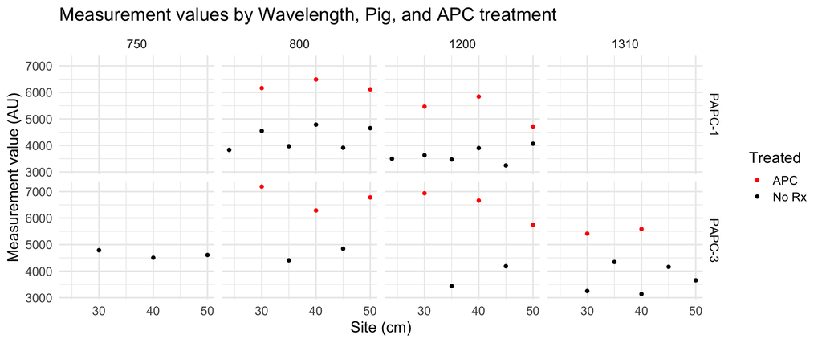

```r
df |>
  ggplot(aes(x = site_cm, y = measurement_value, color = factor(treated))) +
  geom_point() +
  facet_grid(pig ~ wavelength) +
  labs(title = "Measurement values by Wavelength, Pig, and APC treatment",
       x = "Site (cm)",
       y = "Measurement value (AU)",
       color = "Treated") +
  scale_color_manual(values = c("black", "red"),
                     labels = c("No Rx", "APC"),
                     guide = guide_legend(reverse = TRUE)) +
  theme_minimal(base_size = 16)
```